# Prediction Assignment Writeup

Federico Roscioli

5/3/2020

# Prediction Assignment Writeup

## Backgorund

Using devices such as Jawbone Up, Nike FuelBand, and Fitbit it is now possible to collect a large amount of data about personal activity relatively inexpensively. These type of devices are part of the quantified self movement – a group of enthusiasts who take measurements about themselves regularly to improve their health, to find patterns in their behavior, or because they are tech geeks. One thing that people regularly do is quantify how much of a particular activity they do, but they rarely quantify how well they do it. In this project I use data from accelerometers on the belt, forearm, arm, and dumbell of 6 participants. They were asked to perform barbell lifts correctly and incorrectly in 5 different ways. More information is available from the website here: http://web.archive.org/web/20161224072740/http:/groupware.les.inf.puc-rio.br/har (see the section on the Weight Lifting Exercise Dataset).

## Objective

The goal of this project is to predict the manner in which they did the exercise. This is the “classe” variable in the training set. It consists in a report describing how I built your model, how I used cross validation, what I think the expected out of sample error is, and why I made the choices I did.

```r
## preliminary activities
library(ggplot2)
library(caret)
library(randomForest)
library(scales)

## loading data
training <- read.csv("https://d396qusza40orc.cloudfront.net/predmachlearn/pml-training.csv")
testing <- read.csv("https://d396qusza40orc.cloudfront.net/predmachlearn/pml-testing.csv")
```

I proceed to clean the dataset.

```r
## descriptive
str(training)
```

```
## 'data.frame':    19622 obs. of  160 variables:
##  $ X                       : int  1 2 3 4 5 6 7 8 9 10 ...
##  $ user_name               : Factor w/ 6 levels "adelmo","carlitos",..: 2 2 2 2 2 2 2 2 2 2 ...
##  $ raw_timestamp_part_1    : int  1323084231 1323084231 1323084231 1323084232 1323084232 1323084232 1323084232 1323084232 1323084232 1323084232 ...
##  $ raw_timestamp_part_2    : int  788290 808298 820366 120339 196328 304277 368296 440390 484323 484434 ...
##  $ cvtd_timestamp          : Factor w/ 20 levels "02/12/2011 13:32",..: 9 9 9 9 9 9 9 9 9 9 ...
##  $ new_window              : Factor w/ 2 levels "no","yes": 1 1 1 1 1 1 1 1 1 1 ...
##  $ num_window              : int  11 11 11 12 12 12 12 12 12 12 ...
##  $ roll_belt               : num  1.41 1.41 1.42 1.48 1.48 1.45 1.42 1.42 1.43 1.45 ...
##  $ pitch_belt              : num  8.07 8.07 8.07 8.05 8.07 8.06 8.09 8.13 8.16 8.17 ...
##  $ yaw_belt                : num  -94.4 -94.4 -94.4 -94.4 -94.4 -94.4 -94.4 -94.4 -94.4 -94.4 ...
##  $ total_accel_belt        : int  3 3 3 3 3 3 3 3 3 3 ...
##  $ kurtosis_roll_belt      : Factor w/ 397 levels "","-0.016850",..: 1 1 1 1 1 1 1 1 1 1 ...
##  $ kurtosis_picth_belt     : Factor w/ 317 levels "","-0.021887",..: 1 1 1 1 1 1 1 1 1 1 ...
##  $ kurtosis_yaw_belt       : Factor w/ 2 levels "","#DIV/0!": 1 1 1 1 1 1 1 1 1 1 ...
```

[output cut: 86 more lines]

```r
## removing variables with more than 15000 NA
NAs <- sapply(training, function(y) sum(length(which(is.na(y)))))
training <- training[-which(NAs>"15000", arr.ind=T)]

## removing context data
training <- training[-c(1:7)]

#as numeric for correlations
training[, -86] <- sapply(training[, -86] , function(x) as.numeric(x))
```

I split the training dataset in training and testing.

```r
## creating two sets
set.seed(6969)
inTrain <- createDataPartition(training$classe, p=.7, list = F)
trTrain <- training[inTrain,]
trTest <- training[-inTrain,]
```

## Principal Component Analisys

I do some correlation to understand if it is possible to reduce the dimensions.

```r
M <- abs(cor(trTrain[,-86])) #take the absolute values of all the correlation in training
diag(M) <- 0 #set to 0 all carrelation in the diagonal
corcols <- which(M>.8, arr.ind=T) #I want to see only highly correlated variables
dim(corcols)[1]
```

```
## [1] 544
```

```r
preProc <- preProcess(trTrain[,-86], method="pca", thresh = .8) #doing the pca for two components
trainingPC <- predict(preProc, trTrain[,-86]) #predict how the new var will look on the dataset
testPC <- predict(preProc, trTest[,-86])
dim(trainingPC)[2]
```

```
## [1] 13
```

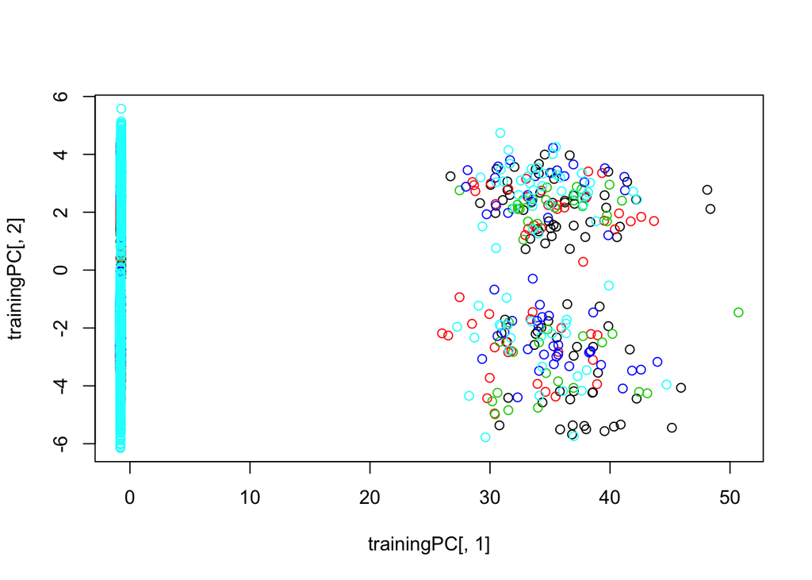

```r
plot(trainingPC[,1], trainingPC[,2], col=trTrain$classe)
```

Now the variations have been reduced to 13.

## Random Forest

I will use Random Forest in order to fit my model and predict the classe.

```r
## random forest
modFit <- randomForest(trTrain$classe~., data=trainingPC, do.trace=F)
modFit
```

```
##
## Call:
##  randomForest(formula = trTrain$classe ~ ., data = trainingPC,      do.trace = F)
##                Type of random forest: classification
##                      Number of trees: 500
## No. of variables tried at each split: 3
##
##         OOB estimate of  error rate: 4.6%
## Confusion matrix:
##      A    B    C    D    E class.error
## A 3799   24   48   29    6  0.02739375
## B   58 2518   70    3    9  0.05267118
## C   39   36 2274   34   13  0.05091820
## D   25   12  113 2084   18  0.07460036
## E    9   31   28   27 2430  0.03762376
```

## Error Level

Let’s evaluate the error level of the model.

```r
## evaluation of the model
error <- confusionMatrix(trTest$classe, predict(modFit, testPC))
error$overall[1]
```

```
##  Accuracy
## 0.9564996
```